# Effect of EBV infection in dRdZ mutant

# Introduction

From Eric’s email:

> What the figure aims to show is that the effect of EBV infection is lost with the dRdZ mutant which looks more like an uninfected NOK with respect to the change in the signature genes upon MC treatment.

We prepare the data, basically load and remove genes with very low counts,

Since we want to obtain the genes that are differentially expressed (upregulated / downregulated) due to the treatment’s effect, we need to prepare two models, one coded in terms of the full model and another in terms of the interactions.

We are going to use the following function to test for hypothesis, contrast needs to be a vectors of the type `c("cat","A","B")`, and is going to test `A vs B` in the `cat` category.

1. Get differentially expressed genes for all genes, and by cell
   - `all_diff_genes` tests the hypothesis of the treatment effect is zero, regardless of treatment
   - `cell_diff_genes` tests the hypothesis of the treatment effect is zero, when the cell is specified.
2. Compare EBV and NOKS differentially expressed genes vs all by `methyl` treat.
   - Upregulated genes

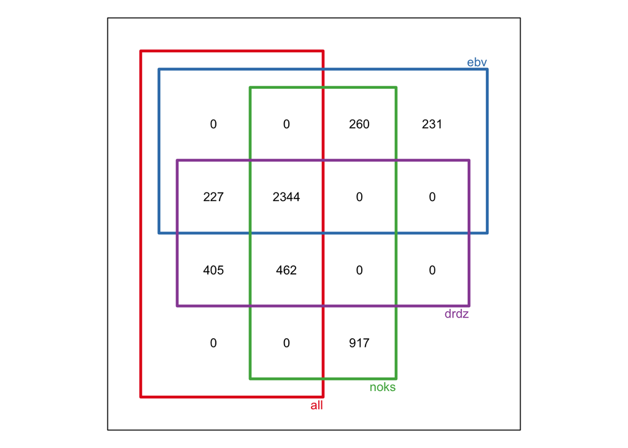

```
- Downregulated genes
```

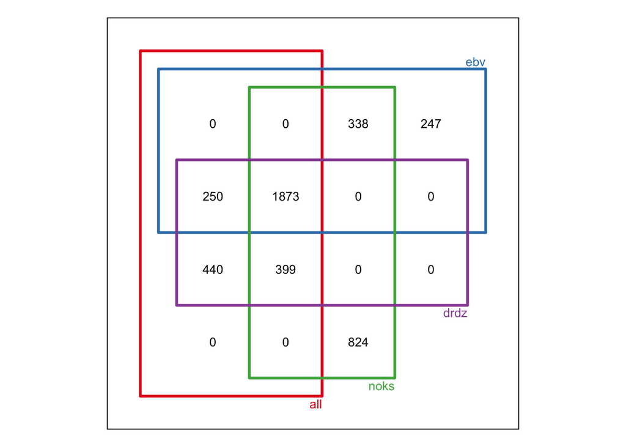

# Recovery: plot from slide

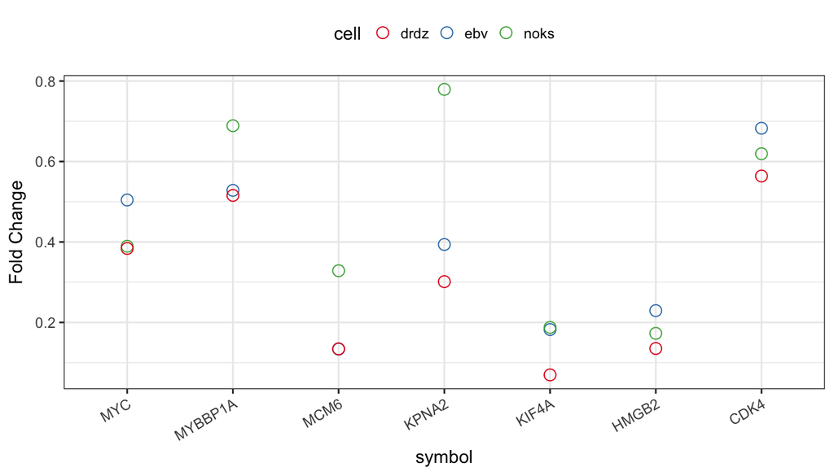

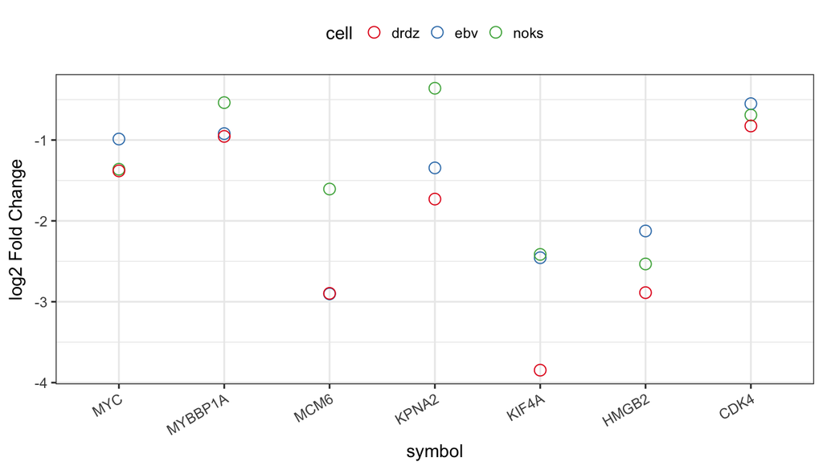

- The ranges and the order of the cells kinda agree, but using the model estimated fold changes, we can see that EBV is not at the top for every gene, where `KPNA2` could be the most notable example.

## Gene sets

We take the genes that are differentially expressed in EBV or NOKS but not the rest.

```
- Upregulated
```

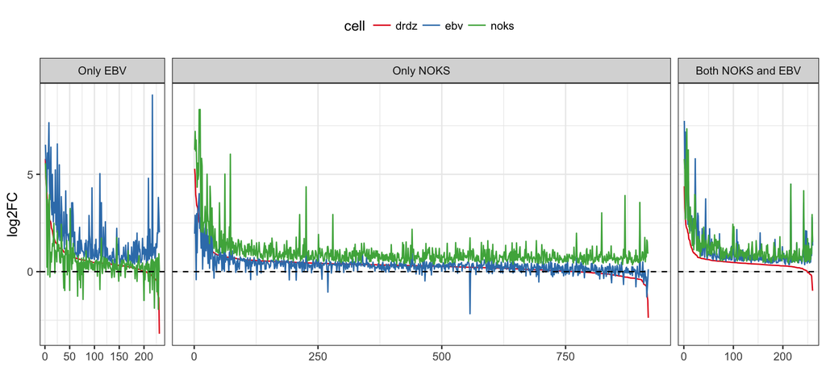

```
- Downregulated
```

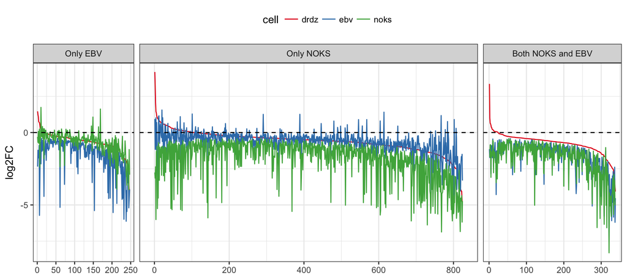

It is hard to tell if there is a relationship in this case. Clearly, there are some genes with the opposite `log2FC` sign than the one expeced (for example positive when checking downregulating genes). Now, we are going to focus in the genes that the there is a large difference between (at least $\geq 2$ ) EBV and NOKS effects:

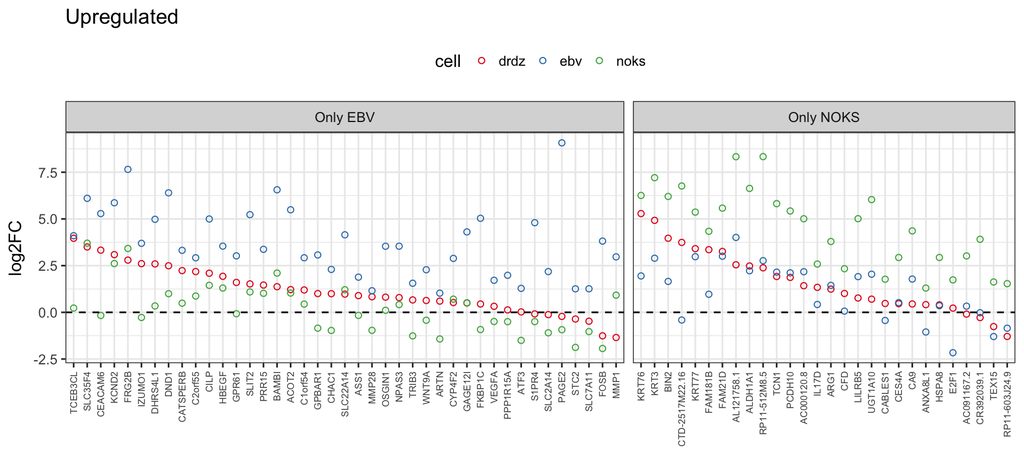

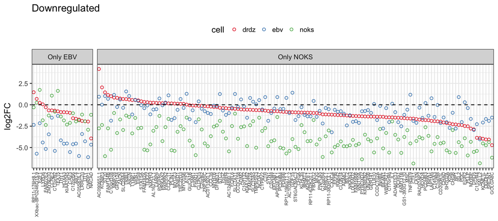